# Movimentos Sociais no Campo · Estrutura Agrária e Assentamentos

Sociologia Rural

Prof. Dr. Luiz Diego Vidal Santos

## Abertura Visão Geral da Aula

Roteiro da aula Tópicos Principais

- 1 Estrutura Agrária no Brasil
- 2 Questão Agrária
- 3 Ligas Camponesas no Nordeste
- 4 MST, CPT e Sindicatos
- 5 Assentamentos em Sergipe

Objetivo Central Luta pela terra e resistência

Analisar a história dos movimentos sociais no campo brasileiro, das Ligas Camponesas ao MST, e o papel dos assentamentos como espaços de resistência.

Ligas Camponesas · CONTAG CPT · MST · CNBB Assentamentos em Sergipe

A organização coletiva no campo é resposta histórica à concentração fundiária e condição para a democratização da terra.

# Estrutura e Questão Agrária

## Estrutura Estrutura Agrária no Brasil

**Definição:** padrão de distribuição e gestão das propriedades das terras agrícolas — regime de propriedade fundiária, produção agrícola e serviços complementares.

**Brasil Colônia · Sesmarias:** concessão de grandes extensões territoriais que originou o latifúndio concentrado.

**Lei de Terras de 1850:** mercantilização do acesso à terra, ligada à política de embranquecimento e bloqueio ao campesinato negro e pobre.

**Século XX · Créditos fundiários:** mecanismos financeiros seletivos de acesso e modernização da propriedade rural.

**Década de 1960 · Revolução Verde:** tecnificação e mecanização concentradora do espaço agrário.

**Atualidade · Internacionalização:** expansão da apropriação e **internacionalização** das terras via comodato.

## Conceito Questão Agrária e Movimentos Sociais

Graziano da Silva (1980) · Veiga (1991) · Kageyama (1993) Questão Agrária vs. Questão Agrícola

- **Questão agrária:** entende o campo enquanto **ambiente social** — formação pública, relações sociais, organização do trabalho, fonte de renda, direito e acesso à terra.
- **Questão agrícola:** trata o campo enquanto **negócio** rural e desempenho produtivo.

Enfrentamento à estrutura patronal Movimentos Sociais no Campo

Surgem da **ausência** dos direitos relativos à questão agrária, focando na **reforma agrária**, no trabalho agrário e na agricultura familiar:

> Representam uma força vital na configuração das relações de propriedade de terra, direitos sociais, políticos e econômicos (Abramovay, 2010).

## Panorama Movimentos Sociais do Campo e Repertórios

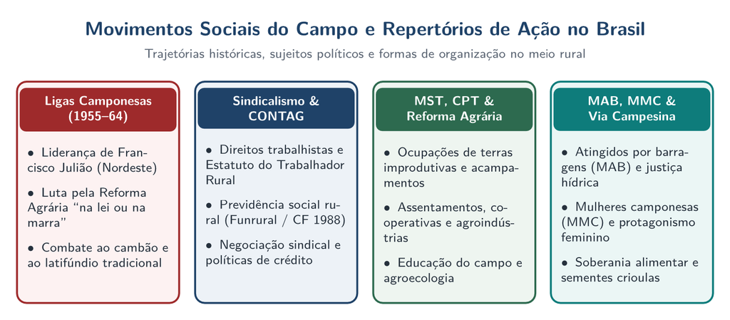

Diagrama comparando quatro grandes repertórios dos movimentos sociais do campo no Brasil: Ligas Camponesas, Sindicalismo & CONTAG, MST, CPT & Reforma Agrária, e MAB, MMC & Via Campesina.

Movimentos Sociais do Campo e Repertórios de Ação no Brasil Trajetórias históricas, sujeitos políticos e formas de organização no meio rural brasileiro

Da luta contra o cambão nas Ligas Camponesas às pautas contemporâneas de agroecologia, justiça hídrica e soberania alimentar.

# Ligas Camponesas, CPT e Sindicatos

## História Ligas Camponesas no Nordeste

**Marco histórico** na luta pela reforma agrária e contra a precarização do trabalho rural:

- Fundação da **Sociedade Agrícola e Pecuária de Pernambuco** (objetivo inicial: cuidar de seus mortos)
- O proprietário ameaçou os foreiros ao perceber aspirações mais amplas

Articulação jurídica e política Francisco Julião e conquistas

Os camponeses procuraram o advogado **Francisco Julião**. Após intensas lutas, conquistaram a **desapropriação** do Engenho Galileia e fundaram núcleos em diversos estados.

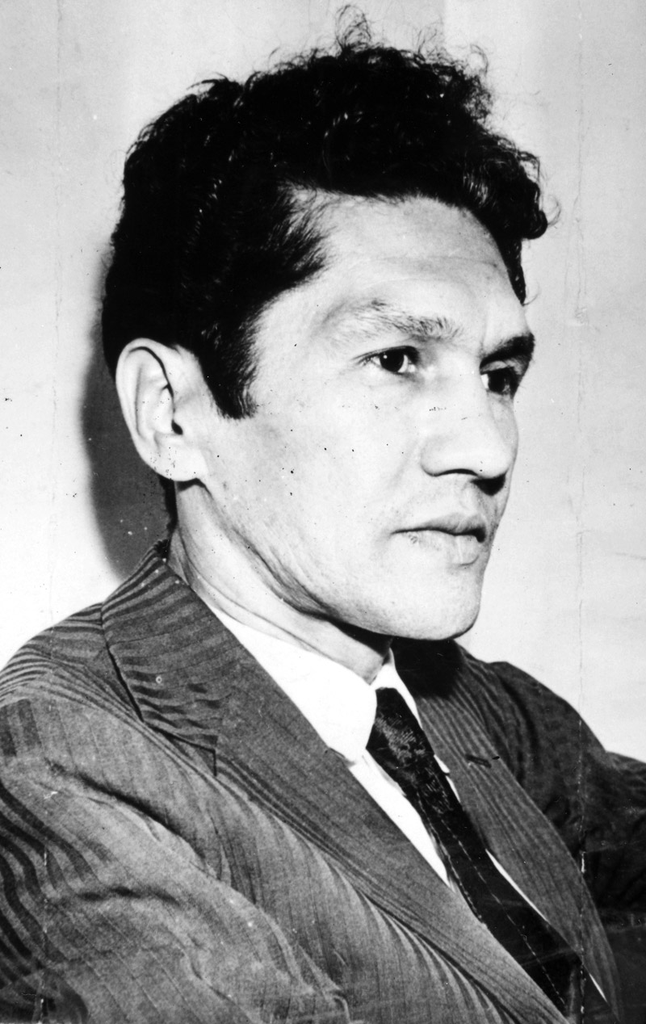

Retrato de Francisco Julião, líder e advogado das Ligas Camponesas.

Francisco Julião, líder das Ligas Camponesas Dvargas97chi / Wikimedia Commons · Licença CC-BY-SA 4.0

## Repressão Ligas Camponesas — Repressão e Legado

Golpe militar de 1964 Desarticulação violenta

- Utilizando como desculpa o perfil “comunista” das ligas (lema: *“a terra na lei ou na marra”*)
- O governo **esmagou** as Ligas Camponesas
- Líderes presos e cerca de **duas mil pessoas** mortas ou desaparecidas

Despertar organizativo Legado histórico

Despertar da **consciência coletiva** no campo — base fundamental para a formação posterior de sindicatos, confederações e demais grupos organizados.

Mesmo sob repressão ditatorial, a experiência das Ligas inaugurou o campesinato como sujeito político nacional no Brasil.

## Igreja e Sindicatos Teoria da Libertação, CPT e CONTAG

Teoria da Libertação · CPT e CNBB Frentes progressistas da Igreja Católica

Surgimento da **Comissão Pastoral da Terra (CPT)** e atuação da **Confederação Nacional dos Bispos do Brasil (CNBB)**:

- Fomento à formação de **sindicatos** e movimentos classistas
- Retórica religiosa entrelaçada com questões **sociopolíticas**
- Eficiente no fortalecimento das discussões e da **consciência coletiva**

1961 · FETAPE, CONTAG e Sindicatos 1º Congresso Nacional dos Lavradores e Trabalhadores Agrícolas

Criação da **CONTAG** (Confederação Nacional dos Trabalhadores na Agricultura):

- Primeira entidade sindical camponesa de **caráter nacional**
- Reconhecida legalmente
- Ajustou diversas concepções: desde setores ligados à Igreja até comunistas

# MST e Assentamentos em Sergipe

## MST Movimento dos Trabalhadores Rurais Sem Terra

1983 · Stedile (1998) Motivos do surgimento

- Expansão dos latifúndios de **soja e trigo** no Sul
- Influência da **Teoria da Libertação** (CPT)
- Experiência anterior do **MASTER**

Atuação contemporânea Atualidade

- Advoga pela **reforma agrária** como redistribuição de recursos
- Cooperativas e associações de **produção agroecológica**
- Entrada na bolsa de valores **B3**

[figure not shown]

Manifestação do Movimento dos Trabalhadores Rurais Sem Terra na Esplanada dos Ministérios em Brasília, 2009.

Manifestação do MST, Brasília (2009) Marcello Casal JR / Agência Brasil · Licença CC-BY 3.0 BR

## Sergipe Assentamentos em Sergipe

Os primeiros movimentos em Sergipe foram movidos principalmente pela **CPT** e pela **Associação de Educação de Base**, dirigidos pela diocese de **Propriá** (Baixo São Francisco).

Canindé do São Francisco Sertão sergipano

Conquista dos assentamentos **Cuiabá** e **Jacaré-Cutuba**.

Poço Redondo Resistência sertaneja

Conquista dos assentamentos **Barra da Onça** e **Barra da Varjinha**.

Neópolis Baixo São Francisco

Conquista do assentamento **Matias de Souza**.

**Alcance regional:** atendimento a mais de **1.000 famílias** assentadas no estado (Silva e Lopes, 1996).

## Xingó Assentamentos — Xingó e Marcha de 1997

Deslocamento compulsório Usina Hidroelétrica de Xingó

Os assentamentos **Cuiabá** e **Curituba** resultaram da **desocupação** de aproximadamente **2.000 famílias** para construção da **Usina Hidroelétrica de Xingó**.

1997 · MST, CPT, FETASE e outros Marcha de quase 200 km

- **Marcha de quase 200 km** até a capital sergipana
- Objetivo: conscientizar os governantes sobre a **distribuição justa de terras**

Hoje, esses assentamentos consolidaram-se como **espaços de formação política e social**, produção agroecológica e organização comunitária.

# Síntese e Referências

## Síntese Conclusão

01 · Origens Das Ligas ao MST

Trajetória contínua de luta por direitos, reforma agrária e dignidade no campo brasileiro.

02 · Mediação Da CPT aos sindicatos

Articulação histórica entre pastorais, sindicalismo rural e organização autônoma dos trabalhadores.

03 · Território Assentamentos

Consolidação dos assentamentos como espaços vivos de **resistência e formação**.

A compreensão dessa trajetória é fundamental para qualquer profissional de **extensão rural** atuar com respeito à história e às organizações do campo.

## Referências Referências da Aula

Bloco 1 · Legislação e Sindicalismo Marcos legais e institucionais

- Brasil. *Lei 5.709/71 — Aquisição por estrangeiro* (1971).
- Brasil. *Lei 5.889/73 — Estatuto do Trabalhador Rural* (1973).
- CONTAG. *40 anos de fundação* (2003).

Bloco 2 · Campesinato e Reforma Agrária História e experiências regionais

- Martins, J. S. *Os Camponeses e a Política no Brasil* (1986).
- Silva, R. *Conflitos de terra e reforma agrária em Sergipe* (1996).
- Stedile, J. P.; Fernandes, B. *Brava Gente* (1998).

Obrigado!

Luiz Diego Vidal Santos

Universidade Estadual de Feira de Santana (UEFS)